# MachineLearningProject

Sujay Nair

7/12/2019

In this project we will analyze the Weight Lifting Dataset and train a model in order to predict the manner in which the participant did the exercise.

### Data Reading

```r
training <- read.csv("pml-training.csv")
testing <- read.csv("pml-testing.csv")
```

### Data Cleaning:

Several of the columns contain all NAs so it’s ok to remove these columns from the dataset. While looking through the data, we see columns with nothing so those colums are also removed.

```r
training <- training[, c(2:10 ,36:49, 60:68, 84:86, 102, 113:124, 140, 151:160)]
testing <- testing[, c(2:10 ,36:49, 60:68, 84:86, 102, 113:124, 140, 151:160)]
notna <- !as.logical(colSums(is.na(training)))
training <- training[, notna]
testing <- testing[,notna]
```

### Exploratory Data Analysis

Here we see that the classe “A” occurs the most and we can see the numbers.

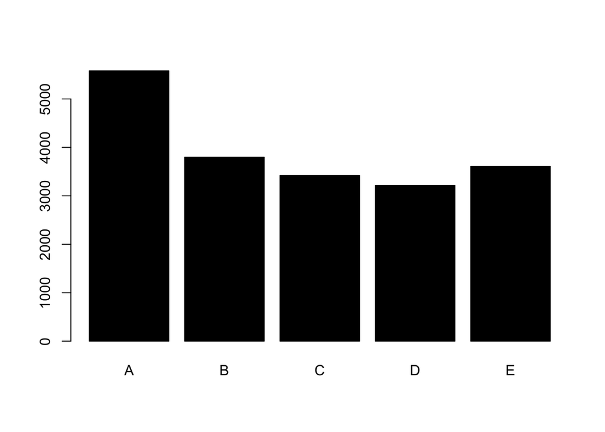

### Creating Validation Sets

15000 is approximately 75% of the data so we split the training into 75% validation training and 25% validation testing.

```r
inTrain = sample(nrow(training), 15000)

validationtrain = training[inTrain,]
validationtest = training[-inTrain,]
```

### Model Training and Estimate Sample Error

```r
mod1 <- train(classe ~., method = "gbm", trControl=trainControl("none"), data = validationtrain, verbose = TRUE)
predval <- predict(mod1, validationtest)
print(mean(predval == validationtest$classe))
```

```
## [1] 0.8372999
```

```r
predtest <- predict(mod1, testing)
```